# Feiyaw_OriginalHomeworkCode_03

Feiya Wang

10/9/2019

## Homework 3 - This file includes comments from Laura Brubaker-Wittman, all at the end of the document.

Introduction: This is the code for [Homework 03](https://fuzzyatelin.github.io/bioanth-stats/homework-03.html), on week 5 of AN597

> Load in the dataset “zombies.csv” from Dr.schimitt GitHub repo.This data includes the first name, last name, and gender of the entire population of 1000 people who have survived the zombie apocalypse and are now ekeing out an existence somewhere on the East Coast, along with several other variables (height, weight, age, number of years of education, number of zombies they have killed, and college major.

```r
library(ggpubr)
library (curl)
#install package curl before this step to load a file from server.

f <- curl("https://github.com/fuzzyatelin/fuzzyatelin.github.io/raw/master/AN597_Fall19/zombies.csv")
#load the file to the variable f

d <- read.csv(f, header = TRUE, sep = ",", stringsAsFactors = FALSE)
#read the .cvs file as a data frame in variable d.

head(d)
```

```
##   id first_name last_name gender   height   weight zombies_killed
## 1  1      Sarah    Little Female 62.88951 132.0872              2
## 2  2       Mark    Duncan   Male 67.80277 146.3753              5
## 3  3    Brandon     Perez   Male 72.12908 152.9370              1
## 4  4      Roger   Coleman   Male 66.78484 129.7418              5
## 5  5      Tammy    Powell Female 64.71832 132.4265              4
## 6  6    Anthony     Green   Male 71.24326 152.5246              1
##   years_of_education                           major      age
## 1                  1                medicine/nursing 17.64275
## 2                  3 criminal justice administration 22.58951
## 3                  1                       education 21.91276
## 4                  6                  energy studies 18.19058
## 5                  3                       logistics 21.10399
## 6                  4                  energy studies 21.48355
```

```r
#show the top 6 rows of the data frame.
```

# Question 1

> Calculate the population mean and standard deviation for each quantitative random variable (height, weight, age, number of zombies killed, and years of education). NOTE: You will not want to use the built in var() and sd() commands as these are for samples."

```r
psd<-function(x){sqrt(sum((x - mean(x))^2)/length(x))}
#function for population standard deviation. psd stand for population standard deviation
```

Then, we could build a table for the quantative variable’s mean and standard deviation

```r
dq<-d[,c(5,6,7,8,10)]
#only get  column 5,6,7,8,10 from the files to from a data frame that only contains the quantative variables.dq stand for quantative data
x<-lapply(dq,mean)
#This is the function i find on website to take mean from data frame, since function mean() cannot use for data-frame strcuture variable, the lapply() will return a vector of function results of each columns in data frame.lapply will apply function to all of the column in data frame dq
y<-lapply(dq, psd)
#as above, also use lapply() and our function psd() to take population standard deviation
table1<-cbind(x,y)
#combine those two vector as a matrix
colnames(table1)<-c("Mean","Population Standard Deviation")
#name each row
table1
```

```
##                    Mean     Population Standard Deviation
## height             67.6301  4.30797
## weight             143.9075 18.39186
## zombies_killed     2.992    1.747551
## years_of_education 2.996    1.675704
## age                20.04696 2.963583
```

If we want to display a nice table like excel format, here is the solution I find from Google

```r
library(knitr)
#install the package of knitr before this step
kable(table1)
```

|  | Mean | Population Standard Deviation |
| --- | --- | --- |
| height | 67.63009808295 | 4.30797010678797 |
| weight | 143.90747819936 | 18.3918570867276 |
| zombies_killed | 2.992 | 1.74755142985836 |
| years_of_education | 2.996 | 1.67570403114631 |
| age | 20.04696112212 | 2.96358265176487 |

# Question 2

> Use {ggplot} to make boxplots of each of these variables by gender.

We frist build a function for all boxplots, all of them shoudl have x=gender, all the outlier color are red and the boxplot itself is dark blue.

```r
library(ggplot2)
#install ggplot2 package before this step
draw_boxplot<-function(dat){
p <- ggplot(data=d, aes(x=gender, y=dat))
#ggplot starting function
p <- p + geom_boxplot(outlier.color = "red",color="dark blue")
#make it into boxplot. normal data are in darkblue, outliers are in red
return (p)
}
```

Then, we apply the function for each quantative variable.

```r
f1<-draw_boxplot(d$height)+ylab("Height")
f2<-draw_boxplot(d$weight)+ylab("Weight")
f3<-draw_boxplot(d$zombies_killed)+ylab("Number of Zombies killed")
f4<-draw_boxplot(d$years_of_education)+ylab("Years of education")
f5<-draw_boxplot(d$age)+ylab("Age")
#apply the build function and add y axis lab to each graph
```

To make it look nice, we combine those graph into one using ggarrange() in package ggpubr. label them by annotate_figure.

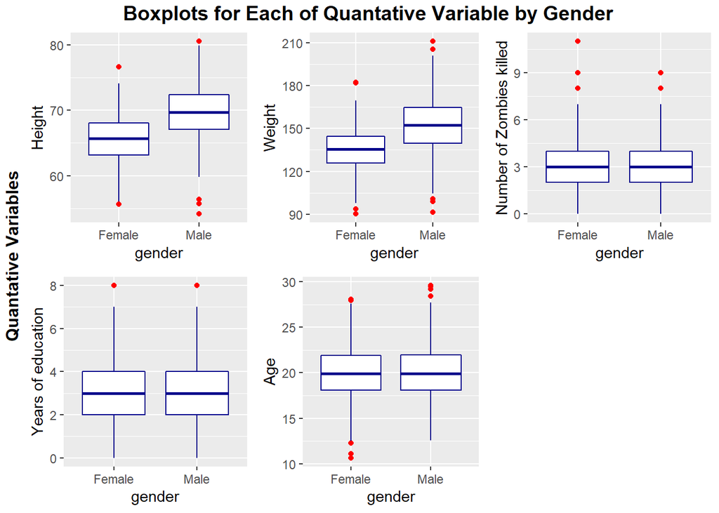

```r
library(ggpubr)
#install package ggpubr before this step.
figure <- ggarrange(f1,f2,f3,f4,f5,
                    ncol = 3, nrow = 2)
# use this unction to combine 5 ggplot into one figure and label it to make it look nice

annotate_figure(
  figure,
  top = text_grob("Boxplots for Each of Quantative Variable by Gender ",
                  color = "black", face = "bold", size = 14),

  left = text_grob("Quantative Variables",
                   color = "black",face = "bold", rot = 90),
  )
```

# Question 3

> Use {ggplot} to make scatterplots of height and weight in relation to age. Do these variables seem to be related? In what way?

We first write a function for scatterplot by ggplot

```r
scatter<-function(r){
p <- ggplot(data=d, aes(x=age,y=r))
# build a ggplot object
P <- p + xlab("Age")
p <- p + geom_point()
# make a scatterplot
p <- p + geom_smooth(method="lm", fullrange=TRUE)
#add a regression line
return (p)
}
```

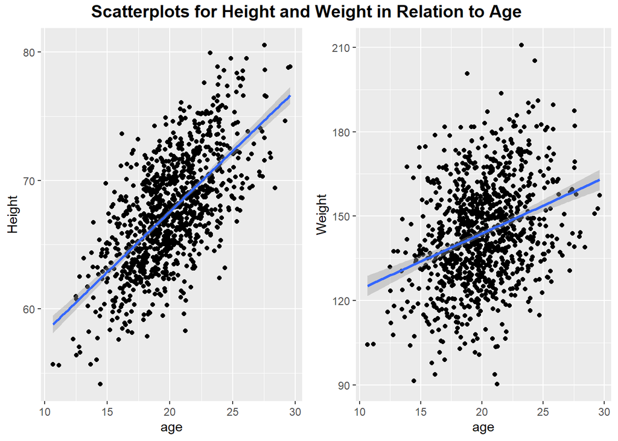

```r
s1 <-scatter(d$height)+ylab("Height")
s2 <-scatter(d$weight)+ylab("Weight")
figure2 <- ggarrange(s1,s2,
                    ncol = 2, nrow = 1)
# use this unction to combine 2 ggplot into one figure and label it to make it look nice

annotate_figure(
  figure2,
  top = text_grob("Scatterplots for Height and Weight in Relation to Age ",
                  color = "black", face = "bold", size = 14),


  )
```

The height and age seems to have a positive linear relationship based on the regression line. However, the weight and age’s relationship is ambigious since there are a lot of outliers from the regression curve.

# Question 4

> Using histograms and Q-Q plots, check whether the quantitative variables seem to be drawn from a normal distribution. Which seem to be and which do not (hint: not all are drawn from the normal distribution)? For those that are not normal, can you determine from which common distribution they are drawn?

First, we build function for histogram with a normal distribution curve, and a Q-Q plot.

```r
his<- function(r){
  lamda<-mean(r)
  #caulcated the mean of data
  pop_se<-psd(r)
  #calculated the standard deviation of data
  h<-curve(dnorm(x, 0, 1), -5, 5, ylim = c(0, 0.8))
  #build the graph of normal distrivution curve of z-score -5 to +5

  z_score<- function(x){
    z <-(x-lamda )/pop_se
    return (z)}
  #build a function to calculate z score

  z <-lapply(r,z_score )
  #use lapply to calculate z score for all data
  z<-as.numeric(z)
  #histogram need x to be numeric. change z from a list to numeric
  hist(z, breaks = seq(from = -5, to = 5, length.out = 20), probability = TRUE,
    add = TRUE)
  #add the histogram of z score
  return (h)
  #return histogram
  }

qq<-function(r){
  l<-qqnorm(r)
  #draw qq plot of data
  qqline(r)
  #draw the line of normal distrbution
  return (l)
  #return qq plot.
  }
```

For Height,weight and ages, both histogram and Q-Q plots shows a normal distribution

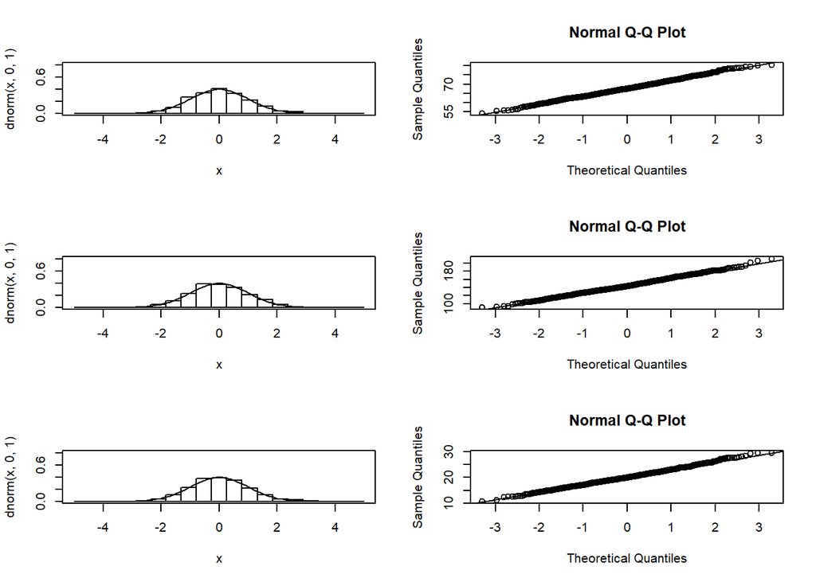

```r
attach(d)
#attach() to use par() function

par(mfrow=c(3,2))
#set a panel of 3 rows and 2 columns
h1<-his(height)
q1<-qq(height)
#draw for height
h2<-his(weight)
q2<-qq(weight)
#draw for weight
h5<-his(age)
q5<-qq(age)
```

```r
#draw for age
```

For the number of zombies they killed and the years of education, although it looks like a normal distribution on histogram, it is not normal distrbution based on the Q-Q plot. Since the similiarity on histograms, i think those two variable might be Poisson Distribution.

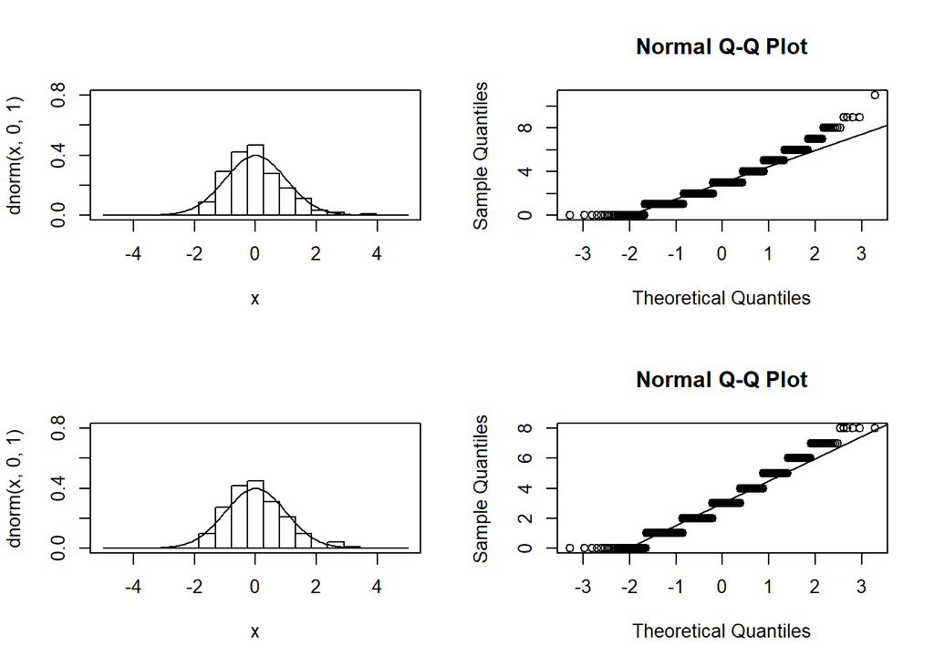

```r
par(mfrow=c(2,2))
#set teh panel of 2 rows and 2 columns
h3<-his(zombies_killed)
q3<-qq(zombies_killed)
#draw for zombies killed
h4<-his(years_of_education)
q4<-qq(years_of_education)
```

```r
#draw for years of education

detach(d)
#need detach for attach()
```

# Question 5

> Now use the sample() function to sample ONE subset of 30 zombie survivors (without replacement) from this population and calculate the mean and sample standard deviation for each variable. Also estimate the standard error for each variable, and construct the 95% confidence interval for each mean. Note that for the variables that are not drawn from the normal distribution, you may need to base your estimate of the CIs on slightly different code than for the normal…

We first build functions to select sample and calculate the data.

```r
#version for normal distribution.
select_n<- function(r){
  x<-sample(r, 30, replace = FALSE)
  #select 30 sample.
  m<-mean(x)
  #take the mean
  sd<-sd(x)
  #take the standard deviation
  ste<-sd(x)/sqrt(length(x))
  #take the standard error
  lower <- m - qnorm(1 - 0.05/2) * ste  # (1-alpha)/2 each in the upper and lower tails of the distribution
  upper <- m + qnorm(1 - 0.05/2) * ste  # (1-alpha)/2 each in the upper and lower tails of the distribution
  ci <- c(lower, upper)
  #take the 95% confidence interval
  v<-c(m, sd, ste,ci)
  #build a vector to store those calculation
  return (v)
  #return the vector
}

#version for Poisson distribution.
select_p<- function(r){
  x<-sample(r, 30, replace = FALSE)
  #select 30 sample.
  m<-mean(x)
  #take the mean
  sd<-sd(x)
  #take the standard deviation
  ste<-sd(x)/sqrt(length(x))
  #take the standard error
  lower <- m - qpois(1 - 0.05/2, m) * ste  # (1-alpha)/2 each in the upper and lower tails of the distribution
  upper <- m + qpois(1 - 0.05/2, m) * ste  # (1-alpha)/2 each in the upper and lower tails of the distribution
  ci <- c(lower, upper)
  #take the 95% confidence interval
  v<-c(m,sd,ste,ci)
  #build a vector to store those calculation
  return (v)
  #return the vector
}
```

Then, we do calculation on each variable:

```r
v1<-select_n(d$height)
v2<-select_n(d$weight)
v3<-select_p(d$zombies_killed)
v4<-select_p(d$years_of_education)
v5<-select_n(d$age)
#calculate each of variables and save the values in vector
t<-rbind(v1,v2,v3,v4,v5)
#combine vector as table
rownames(t)<-c("Height","Weight","Zombies killed","Years of education","Age")
#name row by the data
colnames(t)<-c("Mean","Standard deviation","Standard Error","95% confidence interval lower bound","Higher bound")
#name column as the sequence in function
t
```

```
##                          Mean Standard deviation Standard Error
## Height              67.037961           3.400394      0.6208242
## Weight             146.999011          23.442330      4.2799643
## Zombies killed       2.800000           1.270352      0.2319334
## Years of education   3.433333           2.192201      0.4002394
## Age                 19.930326           2.233798      0.4078338
##                    95% confidence interval lower bound Higher bound
## Height                                      65.8211681    68.254754
## Weight                                     138.6104353   155.387587
## Zombies killed                               1.4083996     4.191600
## Years of education                           0.6316576     6.235009
## Age                                         19.1309867    20.729666
```

Like the first question, to make table look nice, we can do kable()

```r
library(knitr)
kable(t)
```

|  | Mean | Standard deviation | Standard Error | 95% confidence interval lower bound | Higher bound |
| --- | --- | --- | --- | --- | --- |
| Height | 67.037961 | 3.400394 | 0.6208242 | 65.8211681 | 68.254754 |
| Weight | 146.999011 | 23.442330 | 4.2799643 | 138.6104353 | 155.387587 |
| Zombies killed | 2.800000 | 1.270352 | 0.2319334 | 1.4083996 | 4.191600 |
| Years of education | 3.433333 | 2.192201 | 0.4002394 | 0.6316576 | 6.235009 |
| Age | 19.930326 | 2.233798 | 0.4078338 | 19.1309867 | 20.729666 |

# Question 6

> a.Now draw 99 more random samples of 30 zombie apocalypse survivors, and calculate the mean for each variable for each of these samples. Together with the first sample you drew, you now have a set of 100 means for each variable (each based on 30 observations), which constitutes a sampling distribution for each variable. What are the means and standard deviations of this distribution of means for each variable? How do the standard deviations of means compare to the standard errors estimated in [5]?

First, we can use previous unction to select for the sample with small change.

```r
select<- function(r){
  x<-sample(r, 30, replace = FALSE)
  #select 30 sample.
  m<-mean(x)
  #take the mean
  return(m)
}
```

Function to take 100 times more and calculate the mean and standard deviation

```r
select_100<-function(r){
x <- NULL
for (i in 1:100) {
    x[i] <- select(r)}
  # take select function 100 times
  m<-mean(x)
  #caulcated mean
  sd<-psd(x)
  #calculate standard deviation
  v<-c(m,sd)
  #use vector to collect
  return(v)
}
```

Then, we calculated for those 5 variables

```r
v1<-select_100(d$height)
v2<-select_100(d$weight)
v3<-select_100(d$zombies_killed)
v4<-select_100(d$years_of_education)
v5<-select_100(d$age)
#select and calculate
table2<-rbind(v1,v2,v3,v4,v5)
#combine result into table

rownames(table2)<-c("Height","Weight","Zombies killed","Years of education","Age")
#name row by the data
colnames(table2)<-c("Mean","Standard deviation")
table2
```

```
##                         Mean Standard deviation
## Height              67.59313          0.9123335
## Weight             144.12133          3.5928306
## Zombies killed       2.99400          0.3049364
## Years of education   3.00300          0.2982205
## Age                 20.04604          0.5294781
```

Let’s recall the first Table with this table

```r
library(knitr)
kable(table1)
```

|  | Mean | Population Standard Deviation |
| --- | --- | --- |
| height | 67.63009808295 | 4.30797010678797 |
| weight | 143.90747819936 | 18.3918570867276 |
| zombies_killed | 2.992 | 1.74755142985836 |
| years_of_education | 2.996 | 1.67570403114631 |
| age | 20.04696112212 | 2.96358265176487 |

```r
kable(table2)
```

|  | Mean | Standard deviation |
| --- | --- | --- |
| Height | 67.59313 | 0.9123335 |
| Weight | 144.12133 | 3.5928306 |
| Zombies killed | 2.99400 | 0.3049364 |
| Years of education | 3.00300 | 0.2982205 |
| Age | 20.04604 | 0.5294781 |

As we can see, the Means are really similar to the mean of poplution. The standard deviation is much less then the population deviation for all of them, but is similar to the standard error we calculated in question 5.

> b.What do these sampling distributions look like (a graph might help here)? Are they normally distributed? What about for those variables that you concluded were not originally drawn from a normal distribution?

Use previous function with slightly changes

```r
select_f<-function(r){
x <- NULL
for (i in 1:100) {
    x[i] <- select(r)}
  # take select function 100 times
   return(x)
}
```

Draw the graph for them

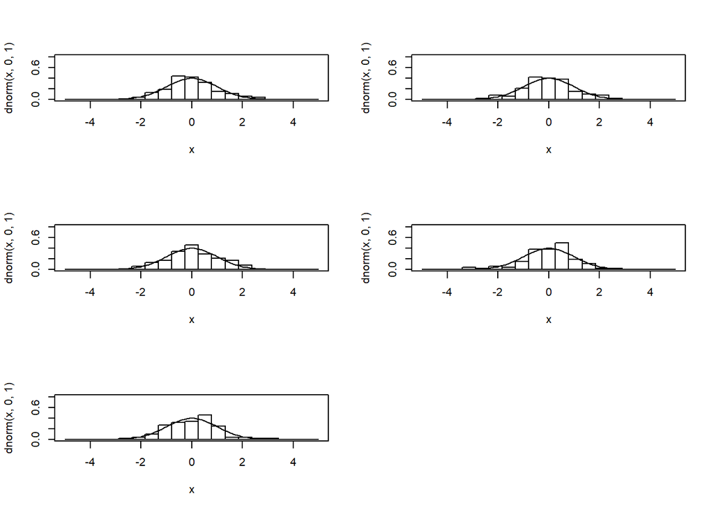

```r
par(mfrow=c(3,2))
h1<-select_f(d$height)
h1f<-his(h1)
h2<-select_f(d$weight)
h2f<-his(h2)
h3<-select_f(d$zombies_killed)
h3f<-his(h3)
h4<-select_f(d$years_of_education)
h4f<-his(h4)
h5<-select_f(d$age)
h5f<-his(h5)
#draw histogram use previous function his()

par(mfrow=c(3,2))
```

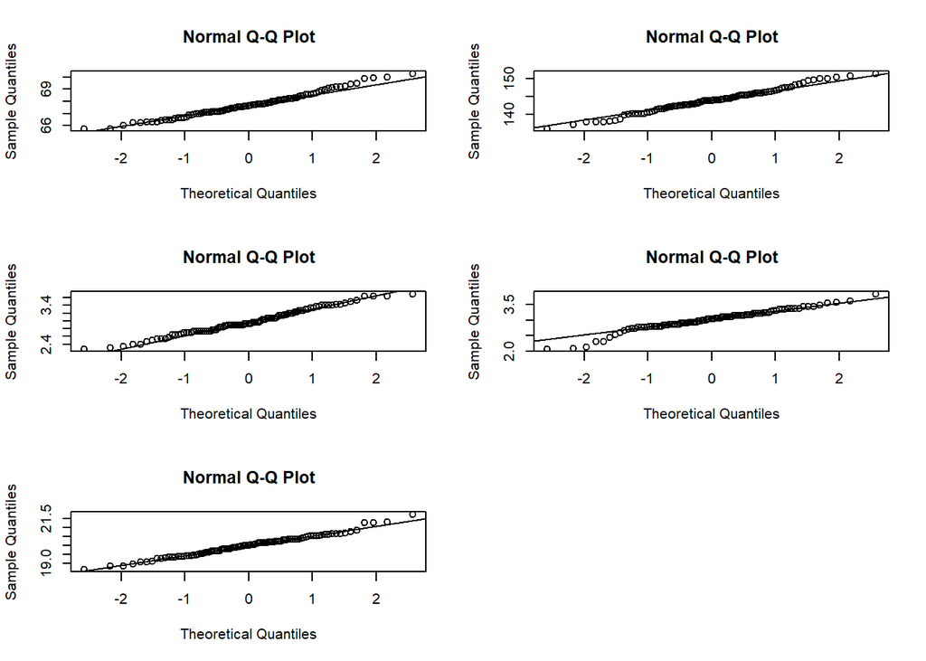

```r
q1<-qq(h1)
q2<-qq(h2)
q3<-qq(h3)
q4<-qq(h4)
q5<-qq(h5)
#draw q-q plot use preivious function qq()
```

From the graph, all pf them have normal distribution, even the poplution are not normal distribution.

## Comments from Laura Brubaker-Wittman:

Around line 48, at the end of question #1, I **LOVE** what you did as far as creating the function for population standard deviation and then applying it to each of the variables we wanted to calcualte at the same time and putting it into a nice table! That made it so easy to read and have all the information together, and defintiely something I will think about how to incorporate into my future work.

Again, with question #2, though I got the same answers as you, I feel like I am learning a lot from your code as far as how I could improve my visuals. Your tables are easy to read, your code is streamlined, and it makes understanding the data that much easier. Awesome job! I defnitely will add {ggpubr} to my package library!

Some of your histograms that go along with your QQplots look different than what I got, but I think that is because I did not have my historgram set up to show negative numbers. I was also unsure what to think of the distributions that showed up as not normal on the QQplots. Poisson may be correct as I know it usually relates to count data over a specific interval of time? I will be interested to hear what Dr. Schmitt says about these.

Like how you once again combined and streamlined data so that it all showed up in one table. This really helped with comparing data.

Overall, amazing job! Looks great.